# statR-vignette

August 2018

Zu jeder Funktion ist mittels Hilfe-Befehl (?) eine Beschreibung sowie ein Verwendungsbeispiel aufrufbar (z.B.: ?splitXLSX )

# 1 Installation

Das Package liegt auf github und kann wiefolgt installiert werden.

```r
library(pacman)

#Variante 1
library(downloader)
download("https://github.com/statistikZH/statR/archive/master.tar.gz", "statR.tar.gz")
install.packages("statR.tar.gz", repos = NULL, type = "source")

#Lade package
library(statR)
```

```r
#Variante 2

library(devtools)

install_github("statistikZH/statR")
```

# 2 Theme

Das ggplot2-theme ist darauf ausgelegt, sich gut ins kantonalen Corporate Design einzufügen.

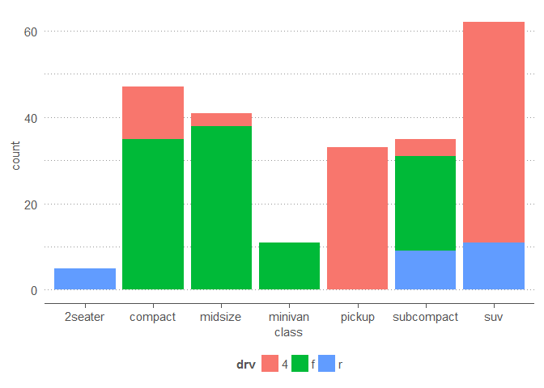

```r
library(ggplot2)

ggplot(mpg, aes(class,fill = drv))+geom_bar()+theme_stat()
```

# 3 Farben

Das Farbpalettenobjekt zhpal, welches alle StatZH-Farbpaletten enthält, ist mit geladenem statR Package global verfügbar.

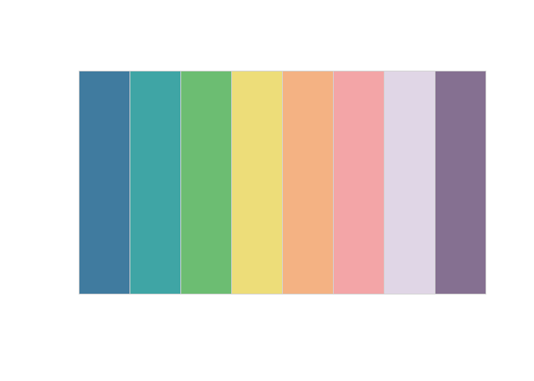

```r
#Zeige Farben an
display(zhpal$zhdiagonal)
```

```r
#Mische 20 Farbtöne auf Basis der zhdiagonal-Palette
colorRampPalette((zhpal$zhdiagonal),space="Lab")(20)
```

```
##  [1] "#3F7A9F" "#418AA1" "#4099A3" "#46A79F" "#5AB08D" "#67B97A" "#8AC473"
##  [8] "#BAD076" "#E6DB78" "#EFCF7C" "#F2BF80" "#F4B184" "#F3AC92" "#F3A79F"
## [15] "#F1ACB0" "#EBBFC7" "#E2D0DF" "#C7BACE" "#A594AF" "#857091"
```

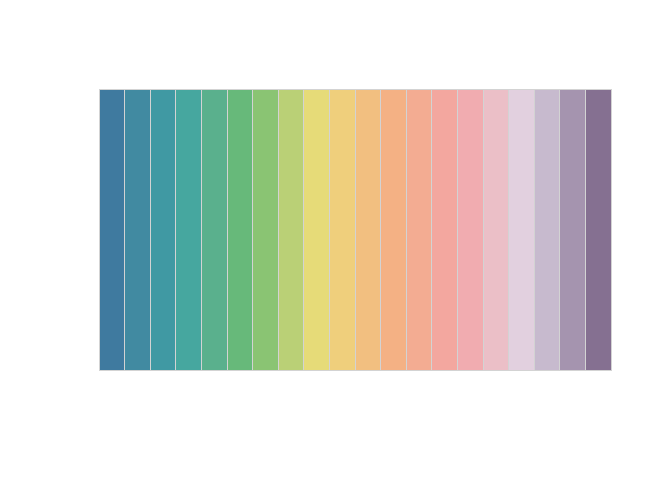

```r
#Zeige die 20 Farben an
display(colorRampPalette((zhpal$zhdiagonal),space="Lab")(20))
```

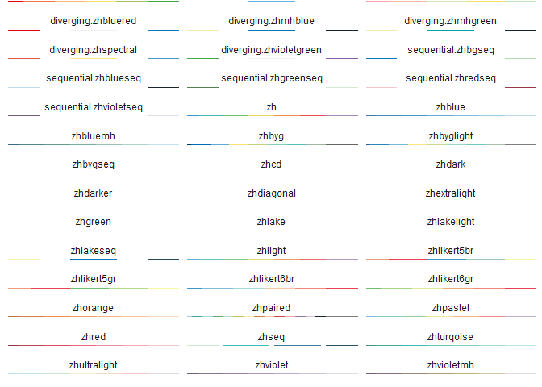

```r
#Alle Paletten auf einen Blick
display.statcol.all()
```

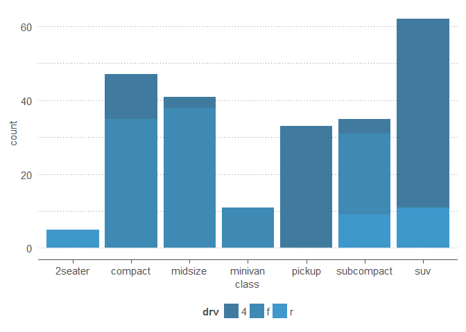

```r
#verwende die Paletten für kategoriale Daten mittels 'scale_fill_manual'
ggplot(mpg, aes(class,fill = drv))+geom_bar()+theme_stat()+scale_fill_manual(values=zhpal$zhblue)
```

# 4 Formattierte ZH Excel-Tabellen mit R

## 4.1 insert_worksheet

```r
#erstelle ein neues Workbook
wb <- openxlsx::createWorkbook("hello")

#schreibe daten in ein neues sheet im bestehenden Workbook
insert_worksheet(mtcars[c(1:25),],wb)

#speichere workbook als xlsx-Datei ab
openxlsx::saveWorkbook(wb, "file.xlsx", overwrite = TRUE)
```

## 4.2 quickXLSX

Schreibt Daten aus R in eine XLSX-Tabelle mit einem einzelnen Arbeitsblatt.

```r
#Beschreibung & Anwendungsbeispiele via '?'
?quickXLSX

#Speichere die obersten Zeilen des mtcars-Datensatzes als formatiertes XLSX File ab
quickXLSX(head(mtcars),"title of the spreadsheet")
```

## 4.3 splitXLSX

Die Funktion splitXLSX erlaubt es Daten aus R in einer XLSX-Tabelle mit mehreren Arbeitsblättern abspeichern. Beispiel: Speichere die ersten 10 Zeilen des mtcars-Datemsatzes in mehreren Arbeitsblättern ab, ein Blatt pro Kategorie der ‘carb’-Variable. Die Funktion eignet sich für Excel-Files welche pro Jahr oder pro Region etc. jeweils einzelne Arbeitsblätter enthalten sollen.

```r
#Beispiel mit Standardlogo (Logo des Statistischen Amtes ZH)
splitXLSX(mtcars[c(1:10),],"mtcars",carb,grouplines=c(1,5,6))

#Beispiel mit modifzierten Bemerkungen und eigenem Logo
splitXLSX(head(mtcars),carb, file="filename",grouplines = c(1,2,3), metadata = "remarks: ....",source="canton of zurich",logo="L:/STAT/08_DS/06_Diffusion/Logos_Bilder/LOGOS/STAT_LOGOS/nacht_map.png")
```